# 拍拍贷用户数据探索

### 日期和业务指标相关因素探究

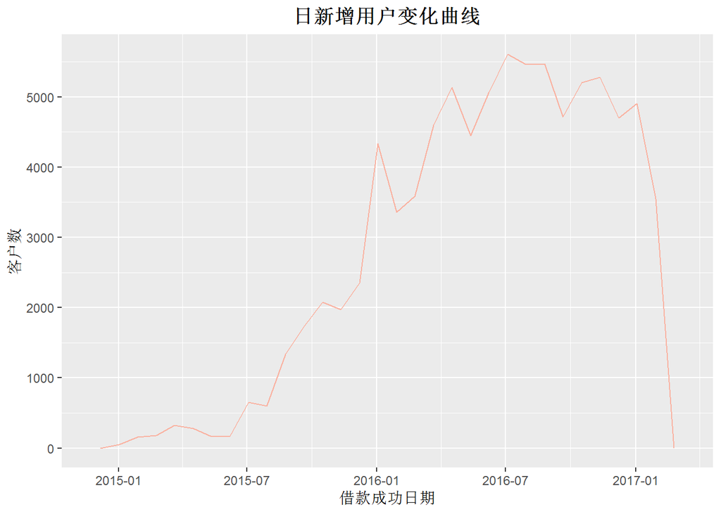

在2015年1月到2016年7月，每日获客数日益增加，在2016年7月到2017年1月日新增用户数趋于稳定，只是小幅波动。

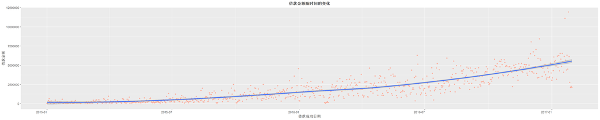

借款金额逐渐增加，反映了平台的借贷业务发展良好。

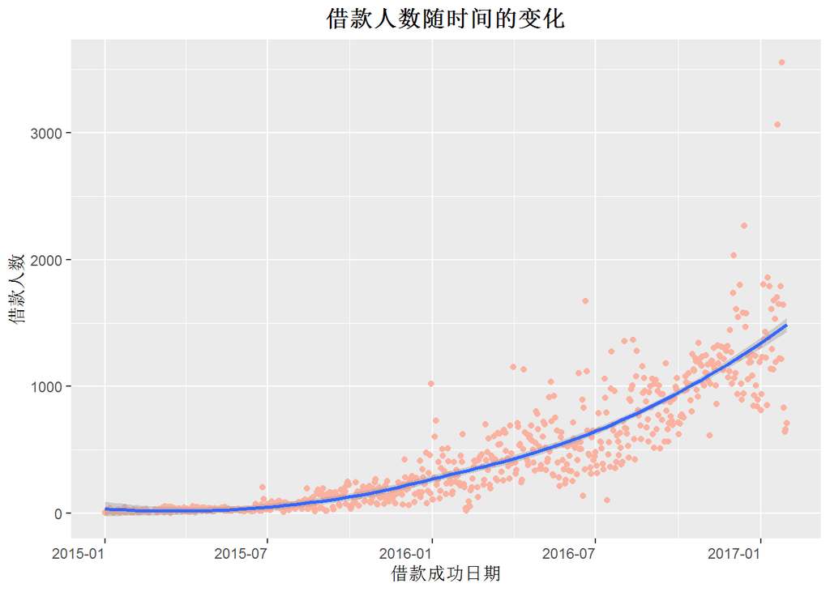

每日的借贷人数逐渐增加，说明平台的业务发展态势良好。

### 探讨你在这部分探究中观察到的一些关系。这些感兴趣的特性与数据集内其他特性有什么区别？

- 探究初始评级和认证数和用户借贷利率之间的关系
- 探究违约率和性别、年龄、借贷利率、初始评级、认证数、借款类型之间的关系
- 探究违约损失率和性别、年龄、借贷利率、初始评级、认证数、借款类型之间的关系
- 探究每日首标人数和日期之间的关系来研究日新增用户数
- 探究每日借款金额、借款人数随时间的变化关系

### 你是否观察到主要特性与其他特性之间的有趣关系？

- 违约率相关因素：
  - 女性的违约率高于男性
  - 违约损失率和年龄、借款利率、借款类型无明显关系。
  - 大体上初始评级越差平均违约率也越高，其中F等级的违约率最高，其次是E等级，A等级的违约率最低。
  - 认证数从0到3平均违约率逐渐升高，之后从4到6又逐渐降低，认证数为0的用户的平均违约率最低。
- 违约损失率相关因素
  - 女性的平均违约损失率高于男性
  - 18到22岁的违约损失率最低，大于22岁，年龄和违约损失率之间呈现负相关，皮尔森相关系数为-0.985。
  - 初始等级越高，平均违约损失率也越高。
  - 认证数3到5的违约损失率相对较高在2以上，其中认证数为4的平均违约率最高，认证数为6的平均违约率最低。
  - 违约损失率和借款利率、借款类型相关性不明显。
- 日期相关的运营业务分析
  - 日新增人数、每日借款金额、每日借款人数随着时间逐渐增大，可见平台的业务发展状态良好。

### 你发现最强的关系是什么？

- 当年纪大于22岁，年龄和违约损失率之间呈现强负相关，皮尔森相关系数为-0.985

# 多变量绘图选择

探究违约损失率和年龄、认证数以及性别之间的关系。

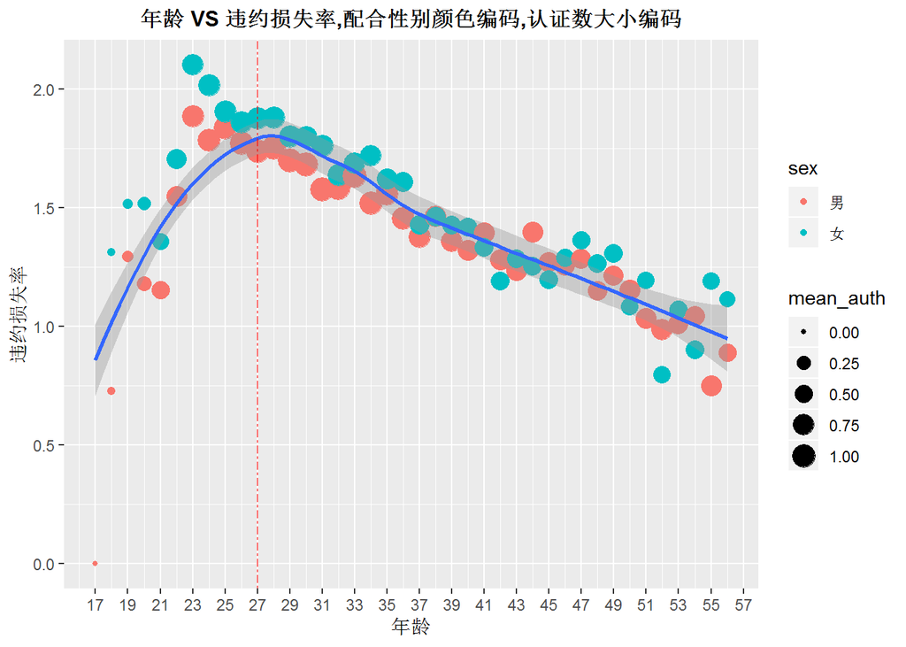

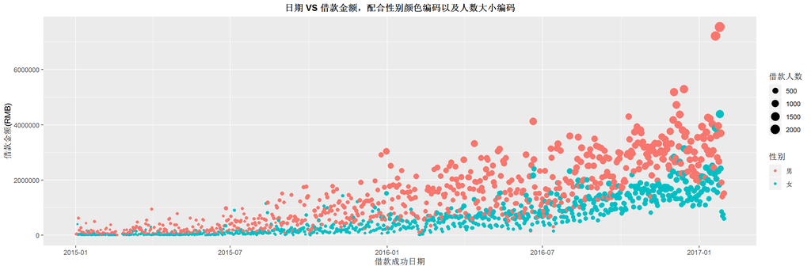

随着时间变化用户的借款金额、借款人数都逐渐增大，反映出业务发展状态良好，而且年龄的借款金额的增长量大于女性。

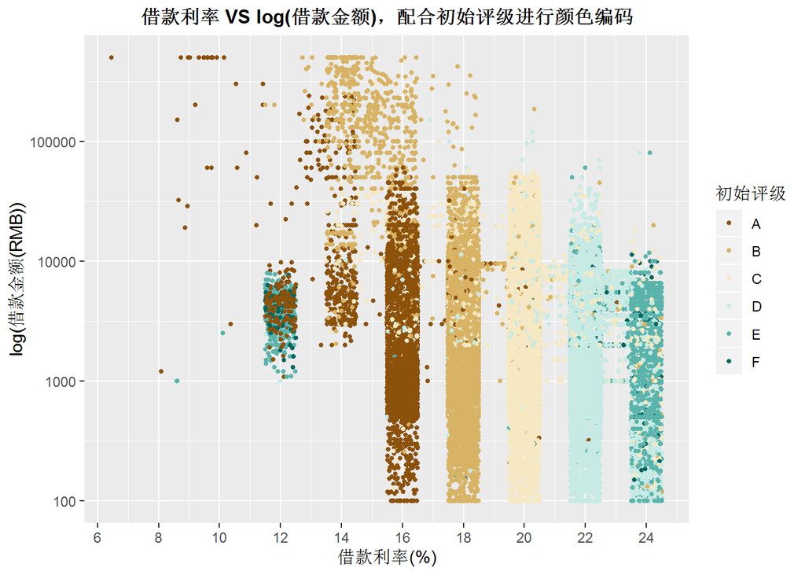

# 多变量分析

### 探讨你在这部分探究中观察到的一些关系。通过观察感兴趣的特性，是否存在相互促进的特性？

- 探究违约损失率随年龄、性别和违约损失率之间的变化关系
- 探究借款金额、借款人数随时间的变化关系

### 这些特性之间是否存在有趣或惊人的联系呢？

- 在27岁以前违约损失率和年纪呈现正相关，在27岁以后违约损失率和年龄呈现负相关，而且女性的违约损失率要高于男性，认证数在年龄变化上无明显的变化。
- 随着时间变化用户的借款金额、借款人数都逐渐增大，反映出业务发展状态良好，而且年龄的借款金额的增长量大于女性。

### 创建过数据集的任何模型？讨论你模型的优缺点。

- 创建对违约损失率根据年龄、性别分组，并据此分别计算违约损失率和认证数的均值。经过前面单变量、双变量探索可以知道违约损失率在年龄大于22岁时，和年纪成反比，同时女性的概率高于男性，并且违约损失率和认证数有一定的关系，通过关键这个新的模型，可以观察到违约损失率随年龄的变化，在性别上的不同表现以及认证数在随年龄的变化关系。

## 借款金额和借款人数是拍拍贷业务的两个重要的相关因素，将这两个指标在实践和性别维度进行分组，研究其随着时间变化趋势，以及和性别的关系。

# 定稿图与总结

## 用户画像分析

用户画像主要从用户的基本信息分析(包含年龄和性别)以及信用信息分析(包含初始评级和认证情况)进行分析。

### 性别和年龄的用户数量分布

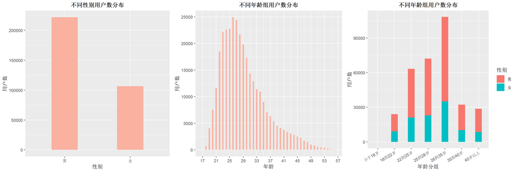

### 认证数和初始评级用户数量分布

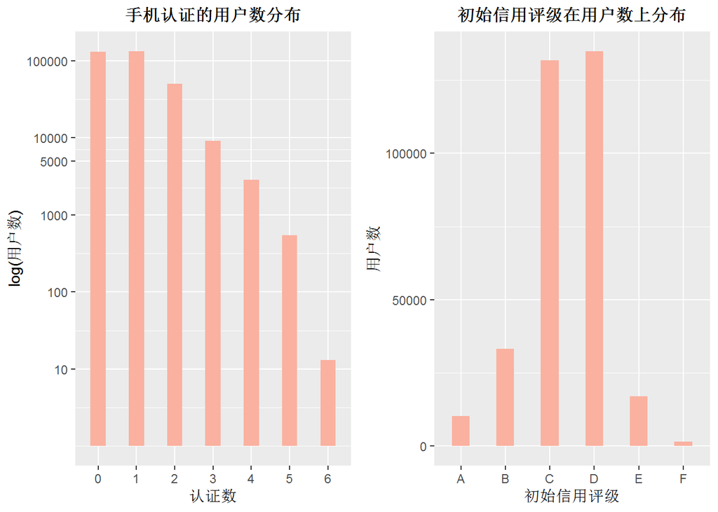

从认证数可以看出在统计的手机认证、户口认证、视频认证、学历认证、征信认证、淘宝认证中，绝大数无认证或者只完成了其中的0到2项认证，只有极少数的人完成了6项认证；在初始等级中可以看到，用户的信用等级为D的用户最多，其次是C，这两者占用户信用等级的绝大多数，没有信用等级在AAA和AA的，从整体上来看用户的初始信用等级不高，需要加强用户信用等级的审核。

## 平台业务基本情况分析

平台业务的基本情况分析主要从借款金额分布、借款期限用户分布、借款类型分布、借款金额分布、是否首标、借款利率分布、平均利率和初始评级间的关系、违约概率分布,违约损失概率分布等角度进行分析。

### 借款金额的用户数量分布情况

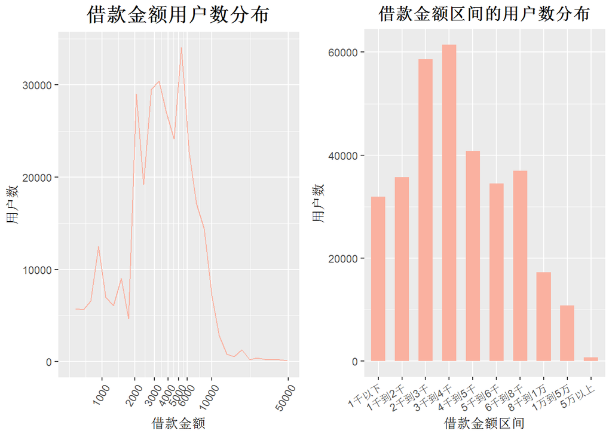

用户的借款金额比较分散，取值范围为100到50万，主要集中在2千到4千。

### 借款期限的用户数量分布情况

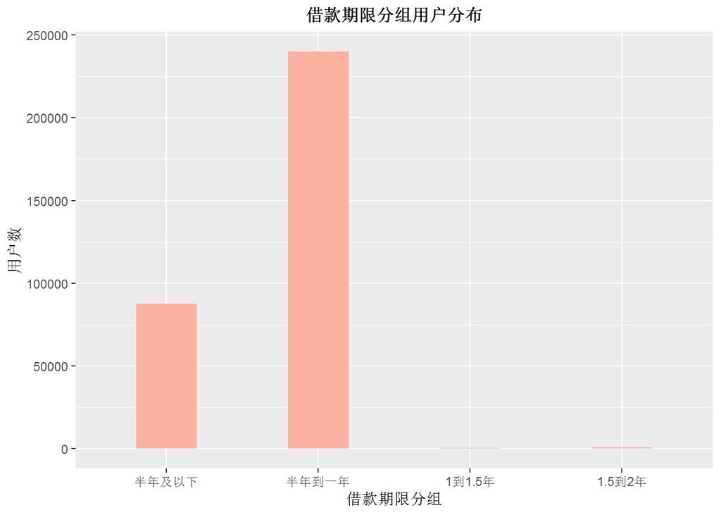

借款期限的数据比较分散，取值范围为1到24个月，按照6个月为间隔将借款期限划分为半年、一年、一年半和两年屏蔽一些不必要的差异，上图可以看到，大多数借款期限集中在半年和一年，其他的用户数很少很少。

### 借款类型的用户数量分布

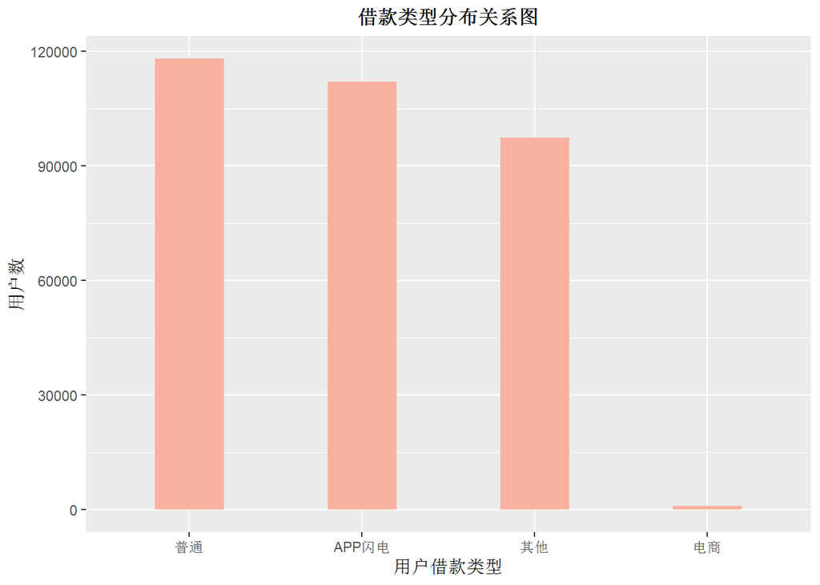

通过观察借款类型，普通性用户最多，其次是APP闪电，再其次是其他，电商用户很少，微乎其微。

### 是否首标用户分布

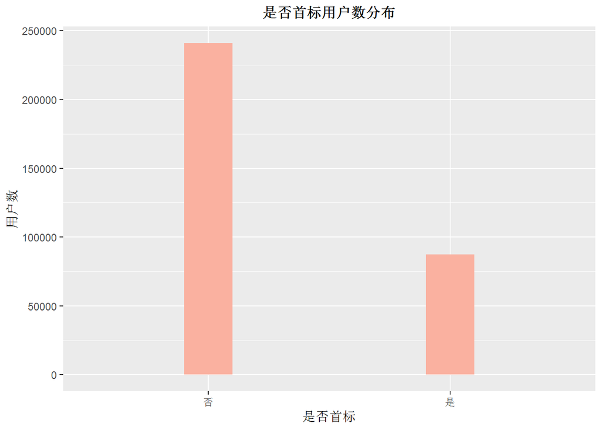

大多数用户不是首标，可见大多数用户是老用户。

### 借款利率用户数分布

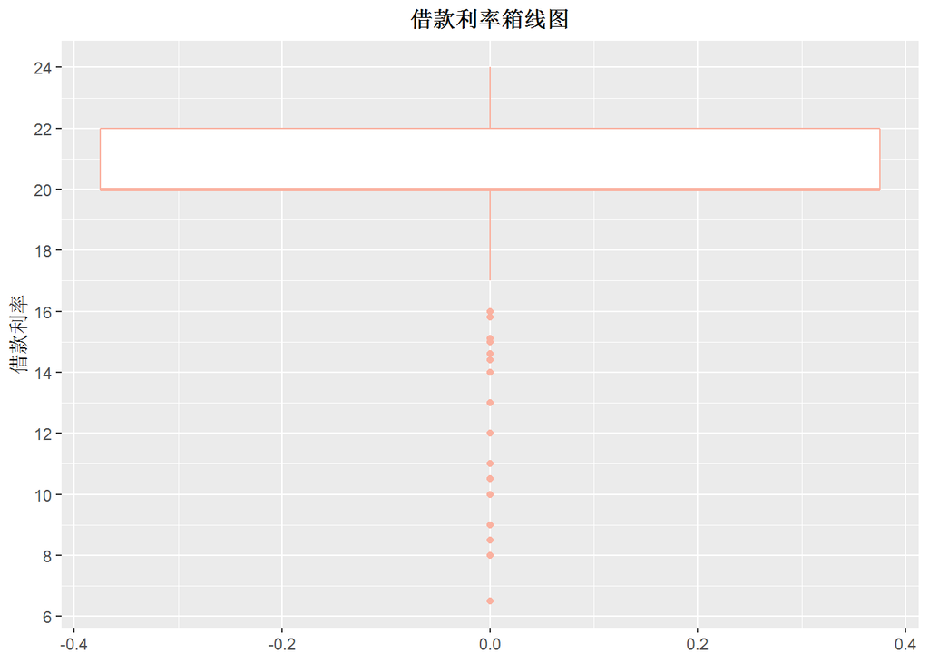

用户的借款利率从6.5%到24%，各个利率阶段用户的数据较为分散，其中20%和22%用户数量分别126330和137899这样的，这两者已经占到总用户的80.4%。

## 平台业务发展情况分析

平台业务业务发展情况，主要从包含借款次数变化、借款金额变化、日新增用户变化情况进行分析。

### 日新增用户变化情况

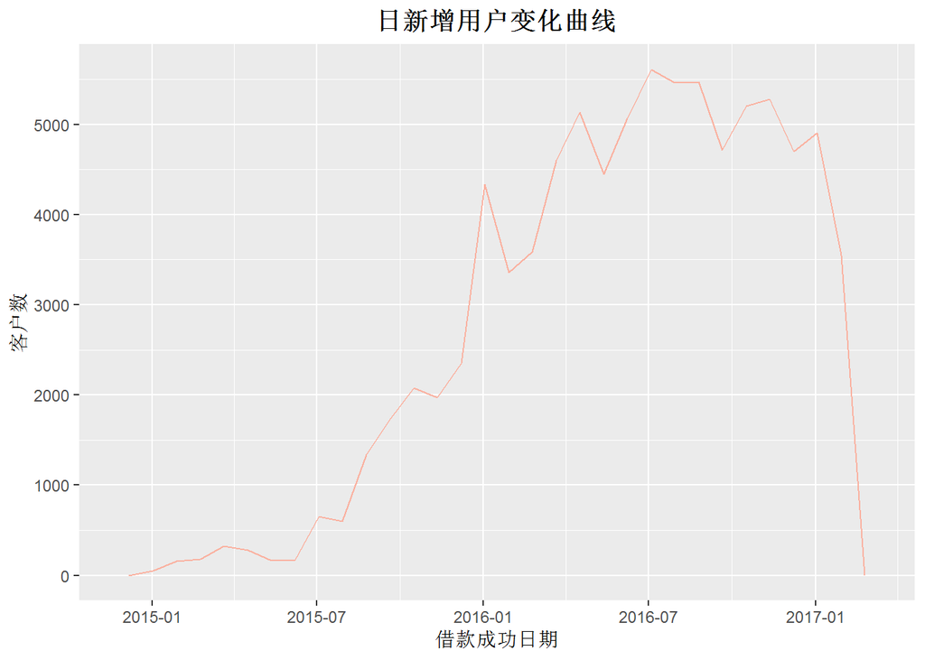

在2015年1月到2016年7月，每日获客数日益增加，在2016年7月到2017年1月日新增用户数趋于稳定，只是小幅波动。

### 日借贷金额变化

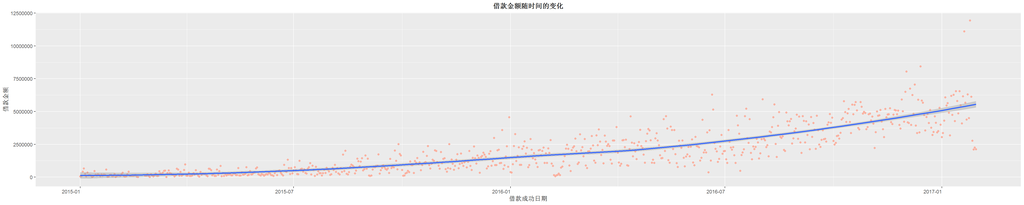

借款金额逐渐增加，反映了平台的借贷业务发展良好。

### 日借贷人数变化

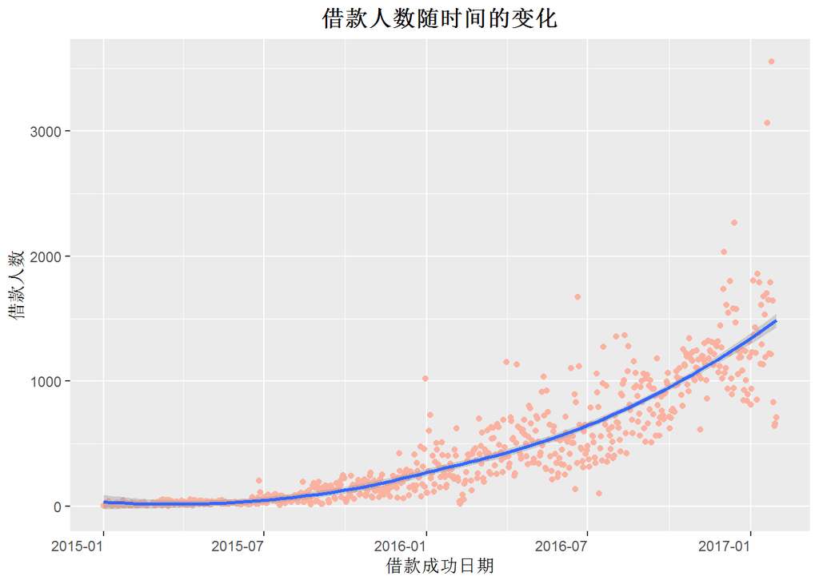

每日的借贷人数逐渐增加，说明平台的业务发展态势良好。

### 借款金额、借款人数随时间变化关系

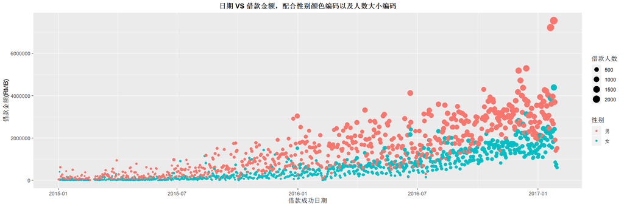

随着时间变化用户的借款金额、借款人数都逐渐增大，反映出业务发展状态良好，而且年龄的借款金额的增长量大于女性。

## 风险指标分析

### 违约损失概率用户分布

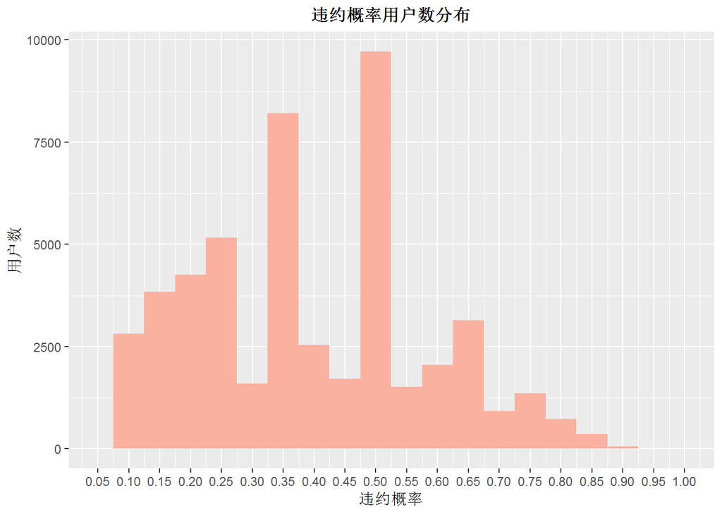

违约概率为0的客户占比为84.7%,违约概率大于0的用户群中0.5出现的概率最高，违约概率0.5的群体占比可达到95%，违约概率低于0.69的客户占比达到99%.

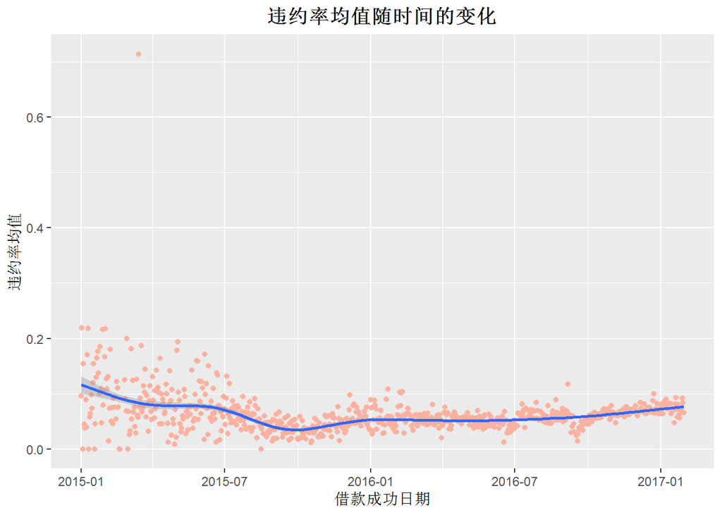

### 违约率相关因素探究

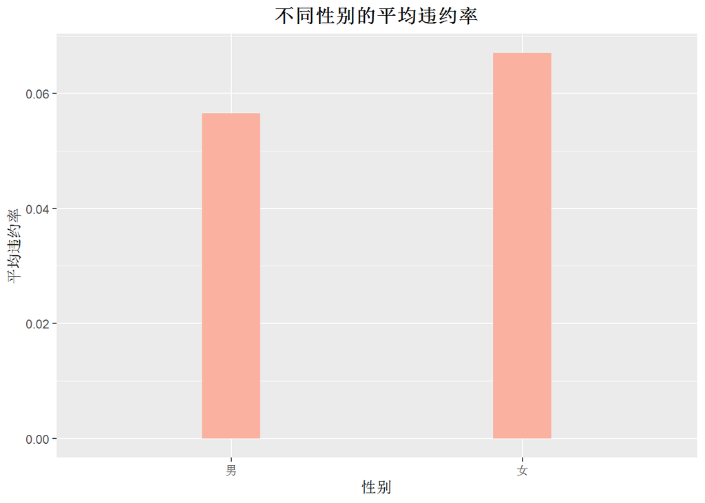

可见女性的违约率高于男性。

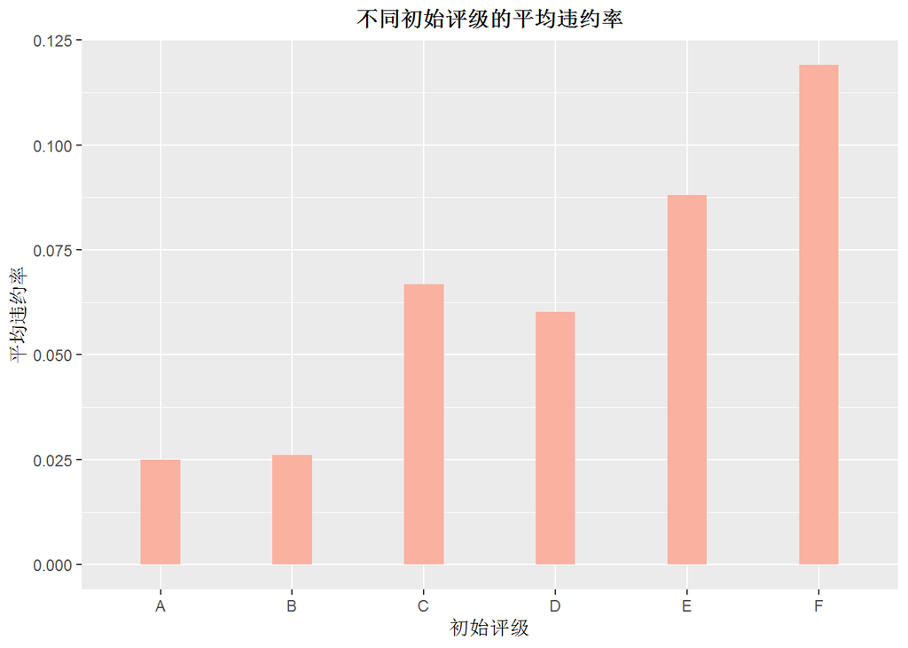

从上图可以看到，大体上初始评级越差平均违约率也越高，其中F等级的违约率最高，其次是E等级，A等级的违约率最低。

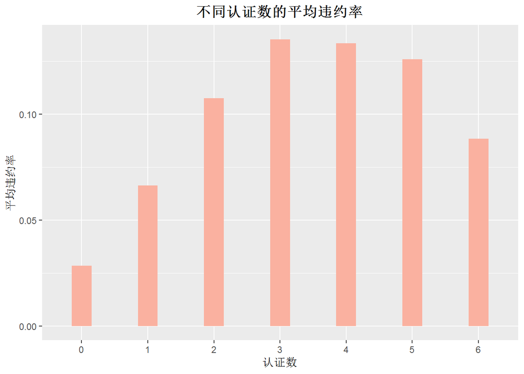

认证数从0到3平均违约率逐渐升高，之后从4到6又逐渐降低，认证数为0的用户的平均违约率最低。

- 女性的违约率高于男性
- 违约损失率和年龄、借款利率、借款类型无明显关系。
- 大体上初始评级越差平均违约率也越高，其中F等级的违约率最高，其次是E等级，A等级的违约率最低。
- 认证数从0到3平均违约率逐渐升高，之后从4到6又逐渐降低，认证数为0的用户的平均违约率最低。

### 违约损失用户分布

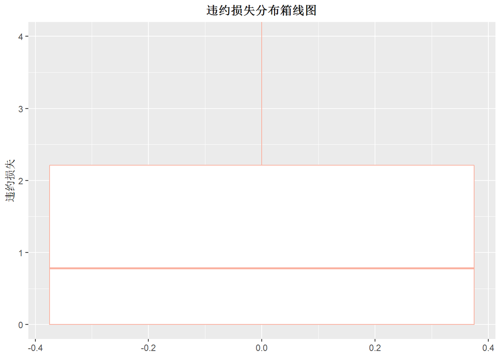

违约损失的分布比较离散，取值范围是0到396.14，中位数是0.78，其中取值为0的用户占比为30.8%，方差分布也不大，违约损失最高可达396.14，平台需要关注用户违约造成的风险程度，对违约损失较高的群体，进行催还款以及对新的贷款申请加强审核和风险告知。

### 违约损失率随时间的变化

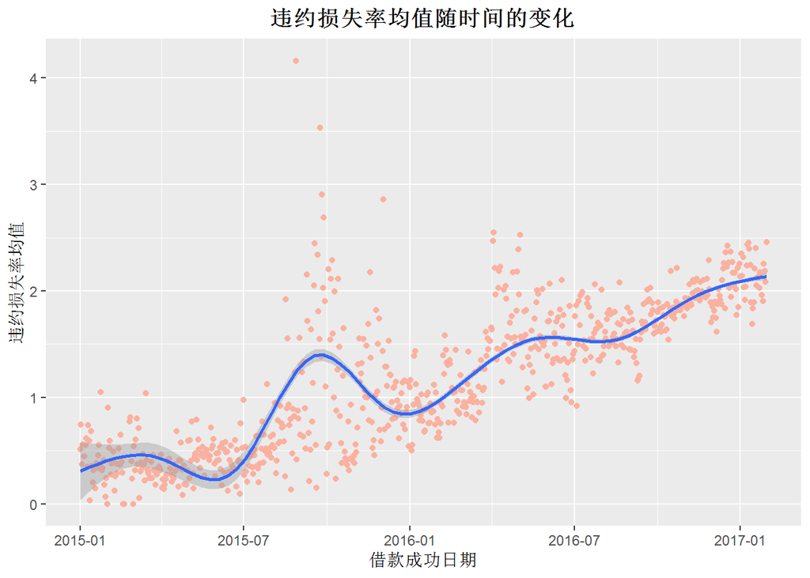

从上图可见，平台的违约损失率盘旋着上升，平台需要加强催款和相关人员的贷款申请的审核。

### 违约损失率相关因素分析

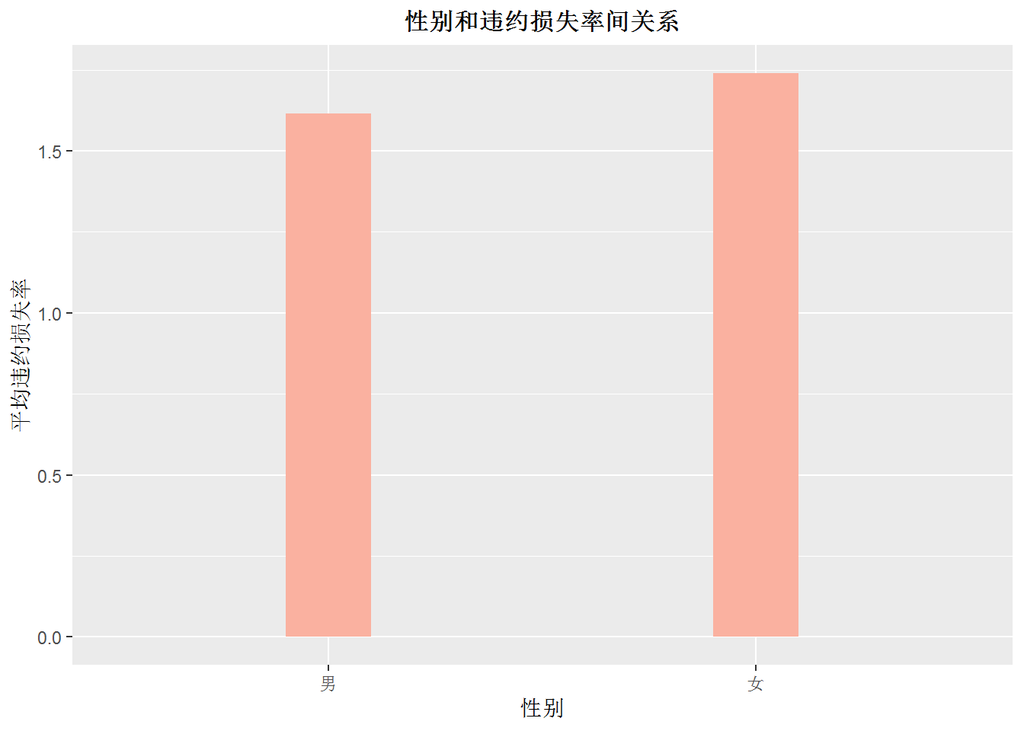

女性的平均违约损失率高于男性。

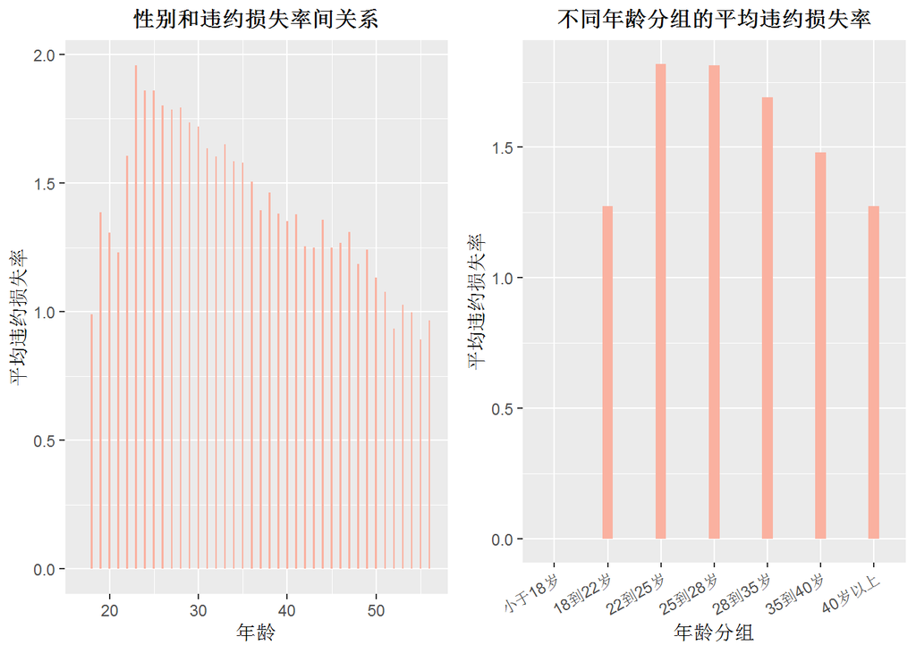

从上图可以看出，18到22岁的违约损失率最低，大于22岁，年龄和违约损失率之间呈现负相关。

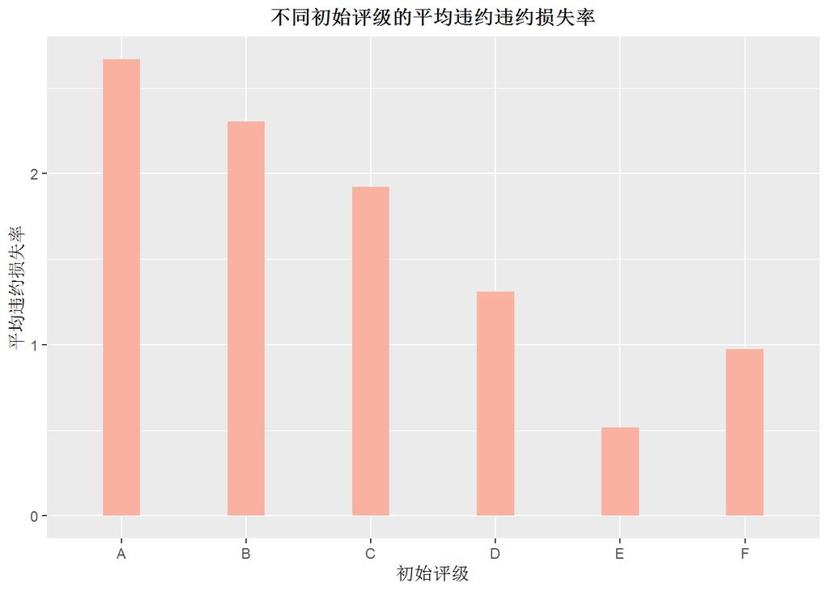

从上可以看到，大体上初始等级越高，平均违约损失率也越高。

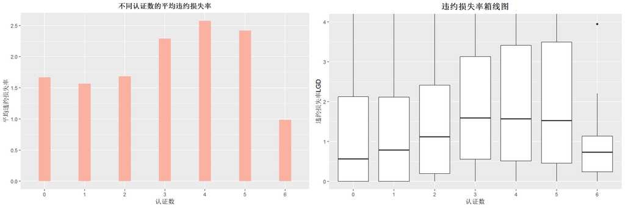

认证数3到5的违约损失率相对较高在2以上，其中认证数为4的平均违约率最高，认证数为6的平均违约率最低。

经过上述相关性探究可知: - 女性的平均违约损失率高于男性 - 18到22岁的违约损失率最低，大于22岁，年龄和违约损失率之间呈现负相关，皮尔森相关系数为-0.985。 - 初始等级越高，平均违约损失率也越高。 - 认证数3到5的违约损失率相对较高在2以上，其中认证数为4的平均违约率最高，认证数为6的平均违约率最低。 - 违约损失率和借款利率、借款类型相关性不明显。

### 违约损失率和年龄性别相关性展示

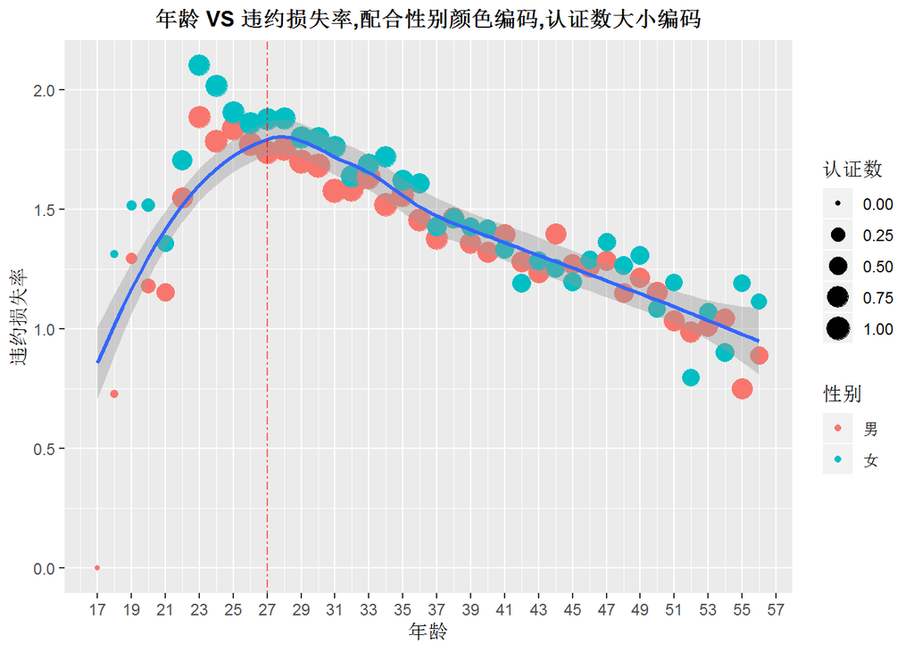

从上图可以看出，当用户年龄小于27岁，违约损失率和年纪呈现正相关，年龄大于27岁，随着年纪增大，违约损失率和年纪呈现负相关，从性别角度观察，各个年级段大都是女性的违约损失率高于男性，而从认证数角度来看，各个年级段的认证数相差不大，17到19岁左右用户的认证数较小，这部分用户群体数量特别小。

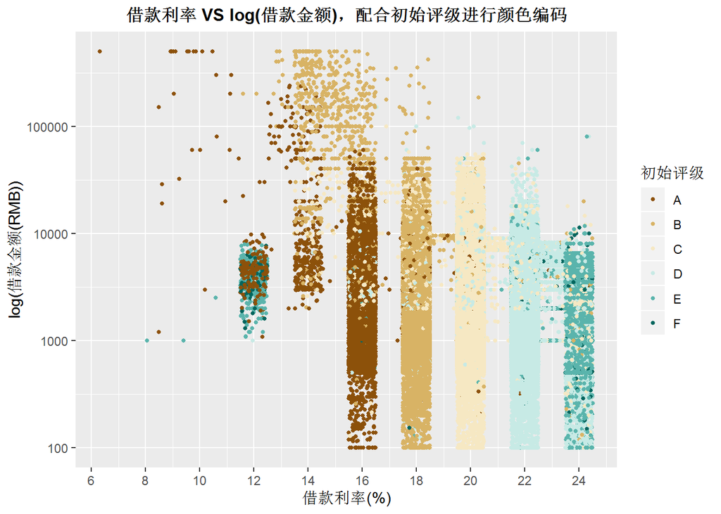

# 反思

通过对业务基本情况的分析，用户的借款金额大多数分布于2000到4000，其中最高可以达到50万，达到50万的用户评级初始评级都位于A和B，而用户的认证数却大多3到4项，依然存在无认证的情况，可以在借款金额上加强对认证数的审核来降低平台的信贷风险。同时不同年龄段借款金额的均值大体随着年龄段的增加而增大，在审核时，可以重点关注一下年龄情况。借款期限的数据比较分散，取值范围为1到24个月，按照6个月为间隔将借款期限划分为半年、一年、一年半和两年屏蔽一些不必要的差异，上图可以看到，大多数借款期限集中在半年和一年，其他的用户数很少很少, 这可能是由于应用的推荐，选择半年和一年期引导了大家的选择意向，借款期限和初始评级以及年龄段无明显关系。大多数用户非首标可见，平台的老用户居多，同时也需要注意平台的引流方式，提高平台的新用户的质量。

观察业务的日新增用户、借贷次数和借贷金额随着时间在增长，而且男性的借款金额大于女性可见平台的业务发展态势良好。

将用户历史逾期次数除以历史逾期次数和历史正常缴款次数得到违约率，违约率大体随着初始评级的降低而升高，违约率和年龄、借款利率、借款类型无明显关系，女性的违约损失率的均值高于男性，在对客户的基础信息分析中可知男性客户占比高于女性；在认证数方面，进行3、4、5项认证的用户的违约率较高，而0项认证的违约率较低，而在信用信息分析中看到0项认证的用户群体更大，平台可以尝试引导用户进行认证，客户可能存在心理顾忌(如信息泄露等)不愿意进行认证，平台可以出台一些措施大小用户的顾忌，引导用户进行认证，同时完善平台信用信息体系。